# lab4

ggplot introduction from: http://www.noamross.net/blog/2012/10/5/ggplot-introduction.html

```r
# install.packages("ggplot2")
library(ggplot2)
```

Letâs say we wanted to plot some two-variable data, changing color and shape by the sub-category of data. Hereâs a data set:

```r
data.df <- data.frame(Plant = c("Plant1", "Plant1", "Plant1", "Plant2", "Plant2", "Plant2"), Type = c(1, 2, 3, 1, 2, 3), Axis1 = c(0.2, -0.4, 0.8, -0.2, -0.7, 0.1), Axis2 = c(0.5, 0.3, -0.1, -0.3, -0.1, -0.8))
```

Using normal R graphics, we might do this:

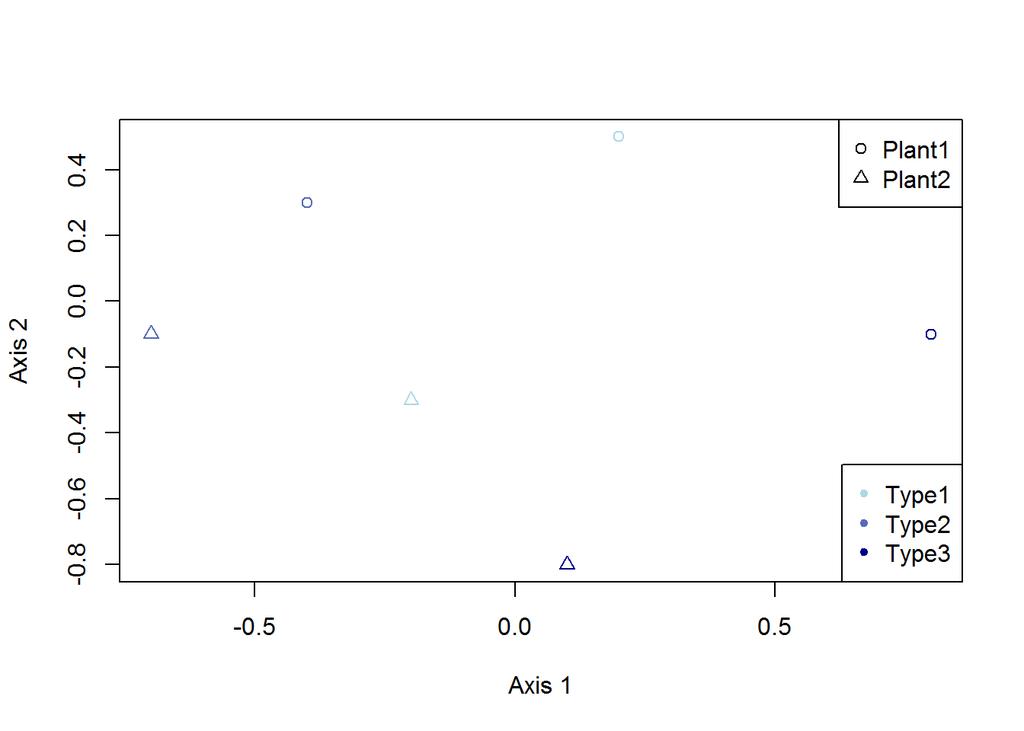

```r
color_foo <- colorRampPalette(c("lightblue", "darkblue"))
colors <- color_foo(3)

plot(range(data.df[, 3]), range(data.df[, 4]), xlab = "Axis 1", ylab = "Axis 2",
    type = "n")
points(data.df$Axis1, data.df$Axis2, pch = c(1, 2)[data.df$Plant], col = colors[data.df$Type])
legend("topright", legend = c("Plant1", "Plant2"), pch = 1:2)
legend("bottomright", legend = c("Type1", "Type2", "Type3"), pch = 20, col = colors)
```

With ggplot, you just do this:

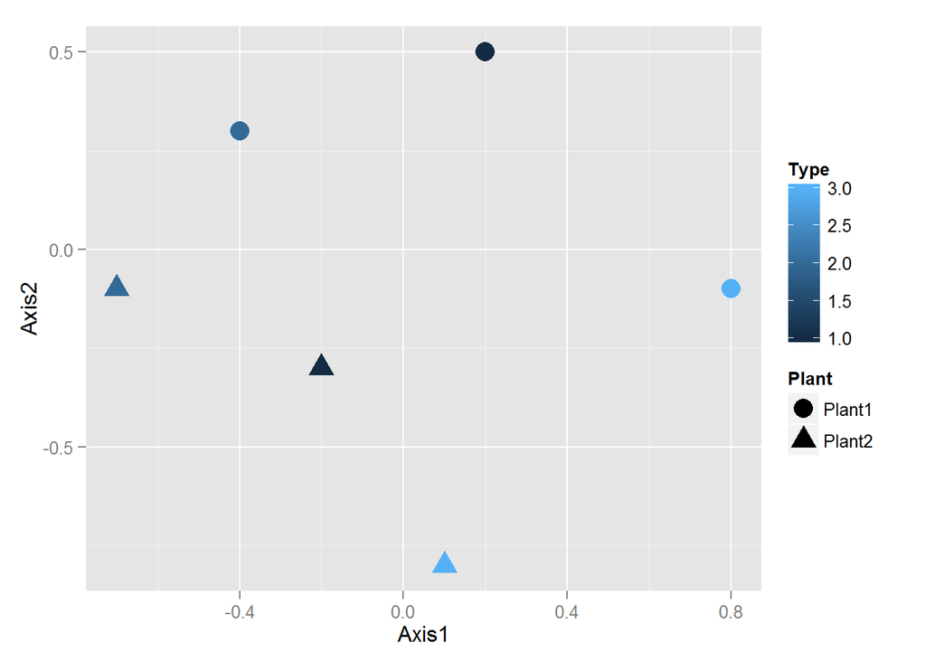

```r
ggplot(data.df, aes(x = Axis1, y = Axis2, shape = Plant, color = Type)) + geom_point(size = 5)
```

And it looks much better!

ggplot is best used on data in data frame form. Letâs look at a data set already in R, this about the sleep habits of different animal species

```r
head(msleep)
```

```
##                         name      genus  vore        order conservation
## 1                    Cheetah   Acinonyx carni    Carnivora           lc
## 2                 Owl monkey      Aotus  omni     Primates         <NA>
## 3            Mountain beaver Aplodontia herbi     Rodentia           nt
## 4 Greater short-tailed shrew    Blarina  omni Soricomorpha           lc
## 5                        Cow        Bos herbi Artiodactyla domesticated
## 6           Three-toed sloth   Bradypus herbi       Pilosa         <NA>
##   sleep_total sleep_rem sleep_cycle awake brainwt  bodywt
## 1        12.1        NA          NA  11.9      NA  50.000
## 2        17.0       1.8          NA   7.0 0.01550   0.480
## 3        14.4       2.4          NA   9.6      NA   1.350
## 4        14.9       2.3   0.1333333   9.1 0.00029   0.019
## 5         4.0       0.7   0.6666667  20.0 0.42300 600.000
## 6        14.4       2.2   0.7666667   9.6      NA   3.850
```

Now, lets start with a basic plot. Letâs create a scatterplot of body weight against total hours sleep:

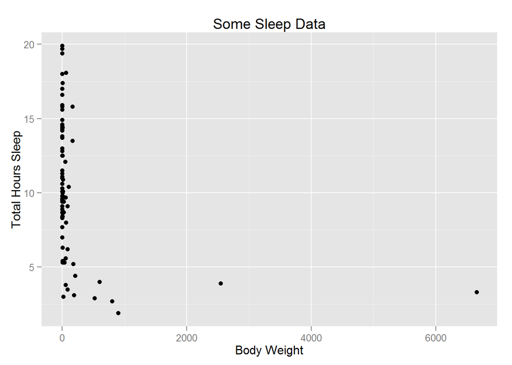

```r
a <- ggplot(data = msleep, aes(x = bodywt, y = sleep_total))
a <- a + geom_point()
a <- a + xlab("Body Weight") + ylab("Total Hours Sleep") + ggtitle("Some Sleep Data")
a
```

Letâs parse what we just did. The ggplot() command creates a plot object. In it we assigned a data set. aes() creates what Hadley Wickham calls an aesthetic: a mapping of variables to various parts of the plot.

We then add components to the plot. geom_point() adds a layer of points, using the base aesthetic mapping. The third line adds labels. Typing the variable name a displays the plot. Alternately, one can use the command ggsave() to save the plot as a file, as in

```r
ggsave("sleepplot.png", plot = a, width = 4, height = 4)
```

Now, one of the great things we can do with ggplot is slice the data different ways. For instance, we can plot another variable against color:

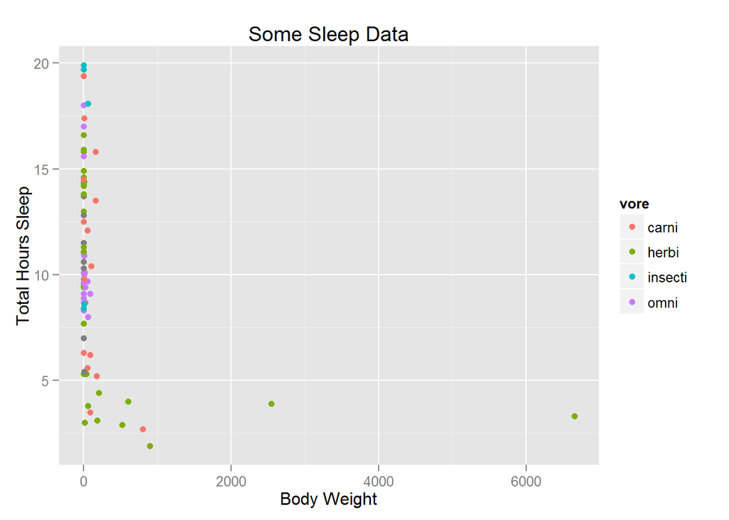

```r
a <- ggplot(data = msleep, aes(x = bodywt, y = sleep_total, col = vore))
a <- a + geom_point()
a <- a + xlab("Body Weight") + ylab("Total Hours Sleep") + ggtitle("Some Sleep Data")
a
```

You can also use map size and alpha (transparency) to variables.

We can transform variables directly in the ggplot call, as well:

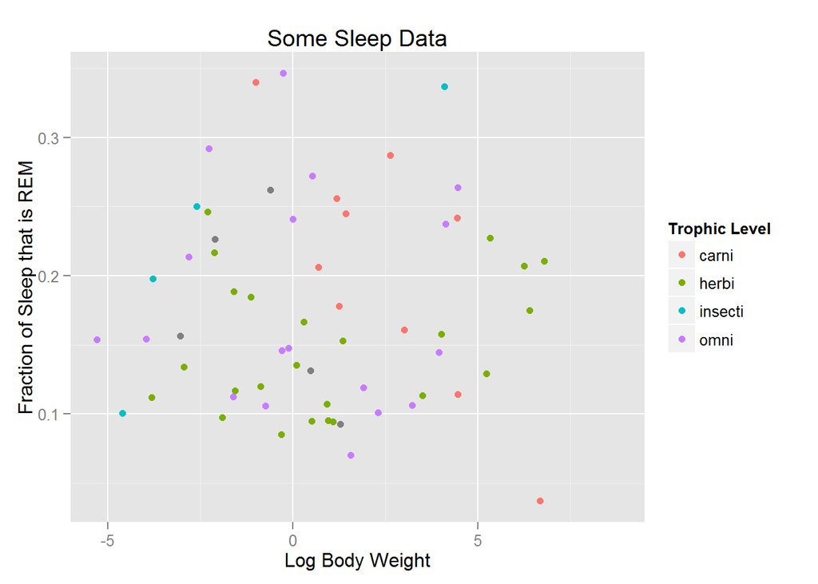

```r
a <- ggplot(data = msleep, aes(x = log(bodywt), y = sleep_rem/sleep_total, col = vore))
a <- a + geom_point()
a <- a + xlab("Log Body Weight") + ylab("Fraction of Sleep that is REM") + ggtitle("Some Sleep Data") +
    scale_color_discrete(name = "Trophic Level")
a
```

Within the geom calls, we can change plotting options

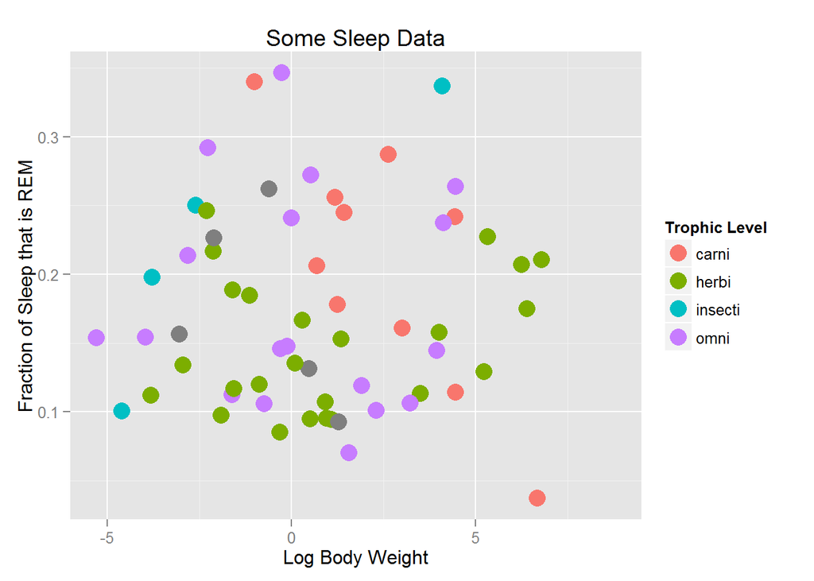

```r
a <- ggplot(data = msleep, aes(x = log(bodywt), y = sleep_rem/sleep_total, col = vore))
a <- a + geom_point(size = 5)
a <- a + xlab("Log Body Weight") + ylab("Fraction of Sleep that is REM") + ggtitle("Some Sleep Data") +
    scale_color_discrete(name = "Trophic Level")
a
```

Another way to split up the way we look at data is with facets. These break up the plot into multiple plots. If you are splitting the plot up by one variable, use facet_wrap. If you are using two variables, use facet_grid.